# PH525.5x Section 3: Management of genome-scale data with Bioconductor

Lauren Kemperman

## Bioconductor Infrastructure: ExpressionSet and SummarizedExperimentSet

- Similar classes of objects - expressionset usually array-based experiments and summarizedexperiment usually sequencing based experiments (rows = genomic ranges)
- Expression set lives in **Biobase** library
- **GeoQuery** allows you to pull down expressionsets by name using GSE identifier. Downloads the expressionset of microarray data
- List with single element in it - access element
- Lots of metadata - **assayData**, **pheontypic data**, **experiment**, **anotations**
- First sample - column indexing
- first row or first feature - row indexing
- Index by name
- **pData** phenotypic data - information about columns of expression set
- as.numeric on factor to see how many replicates of each strain
- pData should have same # of rows as columns in the expression set
- Feature data accessible with **FData** – genes / probe sets. Gene ID, gene symbol
- Experiment data and annotation data

```r
library(Biobase)
library(GEOquery)
geoq <- getGEO("GSE9514")    # download a microarray dataset from GEO
```

```
## Found 1 file(s)
```

```
## GSE9514_series_matrix.txt.gz
```

```
## File stored at:
```

```
## /var/folders/cn/qxqp12fd2gx3m17yb_flfkxc0000gn/T//RtmpWkfqsD/GPL90.soft
```

```r
names(geoq)
```

```
## [1] "GSE9514_series_matrix.txt.gz"
```

```r
e <- geoq[[1]]    # extract ExpressionSet
e
```

```
## ExpressionSet (storageMode: lockedEnvironment)
## assayData: 9335 features, 8 samples
##   element names: exprs
## protocolData: none
## phenoData
##   sampleNames: GSM241146 GSM241147 ... GSM241153 (8 total)
##   varLabels: title geo_accession ... data_row_count (31 total)
##   varMetadata: labelDescription
## featureData
##   featureNames: 10000_at 10001_at ... AFFX-YFL039CM_at (9335 total)
##   fvarLabels: ID ORF ... Gene Ontology Molecular Function (17 total)
##   fvarMetadata: Column Description labelDescription
## experimentData: use 'experimentData(object)'
##   pubMedIds: 18326586
## Annotation: GPL90
```

```r
# exprs gives matrix of microarray values
dim(e)    # number of features and samples in ExpressionSet
```

```
## Features  Samples
##     9335        8
```

```r
ncol(e)
```

```
## Samples
##       8
```

```r
nrow(e)
```

```
## Features
##     9335
```

```r
exprs(e)[1:3,1:3]
```

```
##             GSM241146   GSM241147   GSM241148
## 10000_at     15.33081    9.459372    7.984865
## 10001_at    283.47190  300.729460  270.016080
## 10002_i_at 2569.45360 2382.814700 2711.814500
```

```r
head(exprs(e))[,1]    # first column
```

```
##    10000_at    10001_at  10002_i_at  10003_f_at    10004_at    10005_at
##   15.330812  283.471900 2569.453600 7917.580600    4.744475  253.808090
```

```r
exprs(e)[1,]    # first row
```

```
## GSM241146 GSM241147 GSM241148 GSM241149 GSM241150 GSM241151 GSM241152 GSM241153
## 15.330812  9.459372  7.984865  7.899956  8.710567  7.749938 11.783052  8.327735
```

```r
exprs(e)["10000_at",]    # can also index by name
```

```
## GSM241146 GSM241147 GSM241148 GSM241149 GSM241150 GSM241151 GSM241152 GSM241153
## 15.330812  9.459372  7.984865  7.899956  8.710567  7.749938 11.783052  8.327735
```

```r
rownames(e)[1]    # row names are probe sets
```

```
## [1] "10000_at"
```

```r
dim(exprs(e))    # rows are features, columns are samples
```

```
## [1] 9335    8
```

```r
# pData gives phenotype data (sample information)
pData(e)[1:3,1:6]
```

```
##                                                                           title
## GSM241146 hem1 strain grown in YPD with 250 uM ALA (08-15-06_Philpott_YG_S98_1)
## GSM241147    WT strain grown in YPD under Hypoxia (08-15-06_Philpott_YG_S98_10)
## GSM241148    WT strain grown in YPD under Hypoxia (08-15-06_Philpott_YG_S98_11)
##           geo_accession                status submission_date last_update_date
## GSM241146     GSM241146 Public on Nov 06 2007     Nov 02 2007      Aug 14 2011
## GSM241147     GSM241147 Public on Nov 06 2007     Nov 02 2007      Aug 14 2011
## GSM241148     GSM241148 Public on Nov 06 2007     Nov 02 2007      Aug 14 2011
##           type
## GSM241146  RNA
## GSM241147  RNA
## GSM241148  RNA
```

```r
names(pData(e))
```

```
##  [1] "title"                   "geo_accession"
##  [3] "status"                  "submission_date"
##  [5] "last_update_date"        "type"
##  [7] "channel_count"           "source_name_ch1"
##  [9] "organism_ch1"            "characteristics_ch1"
## [11] "molecule_ch1"            "extract_protocol_ch1"
## [13] "label_ch1"               "label_protocol_ch1"
## [15] "taxid_ch1"               "hyb_protocol"
## [17] "scan_protocol"           "description"
## [19] "data_processing"         "platform_id"
## [21] "contact_name"            "contact_email"
## [23] "contact_department"      "contact_institute"
## [25] "contact_address"         "contact_city"
## [27] "contact_state"           "contact_zip/postal_code"
## [29] "contact_country"         "supplementary_file"
## [31] "data_row_count"
```

```r
pData(e)$characteristics_ch1    # column in GEO to describe experimental state/condition
```

```
## [1] "BY4742 hem1 delta strain" "BY4742"
## [3] "BY4742"                   "BY4742 hem1 delta strain"
## [5] "BY4742 hem1 delta strain" "BY4742 hem1 delta strain"
## [7] "BY4742 strain"            "BY4742 strain"
```

```r
as.numeric(pData(e)$characteristics_ch1)    # help see replicates of each state
```

```
## [1] NA NA NA NA NA NA NA NA
```

```r
dim(pData(e))    # rows of pData correspond to columns of exprs
```

```
## [1]  8 31
```

```r
dim(e)
```

```
## Features  Samples
##     9335        8
```

```r
# fData gives feature data (probe information)
fData(e)[1:3,1:3]
```

```
##                    ID     ORF SPOT_ID
## 10000_at     10000_at YLR331C
## 10001_at     10001_at YLR332W
## 10002_i_at 10002_i_at YLR333C
```

```r
dim(fData(e))    # rows of fData correspond to rows of exprs
```

```
## [1] 9335   17
```

```r
names(fData(e))
```

```
##  [1] "ID"                               "ORF"
##  [3] "SPOT_ID"                          "Species Scientific Name"
##  [5] "Annotation Date"                  "Sequence Type"
##  [7] "Sequence Source"                  "Target Description"
##  [9] "Representative Public ID"         "Gene Title"
## [11] "Gene Symbol"                      "ENTREZ_GENE_ID"
## [13] "RefSeq Transcript ID"             "SGD accession number"
## [15] "Gene Ontology Biological Process" "Gene Ontology Cellular Component"
## [17] "Gene Ontology Molecular Function"
```

```r
head(fData(e)$"Gene Symbol")
```

```
## [1] ""       "MID2"   "RPS25B" "RPS25B" ""       "NUP2"
```

```r
head(rownames(e))
```

```
## [1] "10000_at"   "10001_at"   "10002_i_at" "10003_f_at" "10004_at"
## [6] "10005_at"
```

```r
# additional annotation tied to ExpressionSet
experimentData(e)
```

```
## Experiment data
##   Experimenter name: Olga,,Protchenko
##   Laboratory:
##   Contact information: olgap@intra.niddk.nih.gov
##   Title: Changes in gene expression in response to heme deficiency and hypoxia
##   URL: https://www.ncbi.nlm.nih.gov/geo/query/acc.cgi?acc=GSE9514
##   PMIDs: 18326586
##
##   Abstract: A 33 word abstract is available. Use 'abstract' method.
##   notes:
##    contact_address:
##       10 Center Dr, Bldg.10-Rm.9B-05
##    contact_city:
##       Bethesda
##    contact_country:
##       USA
##    contact_department:
##       NIDDK
##    contact_email:
##       olgap@intra.niddk.nih.gov
##    contact_institute:
##       National Institutes of health
##    contact_name:
##       Olga,,Protchenko
##    contact_state:
##       MD
##    contact_zip/postal_code:
##       20892
##    contributor:
##       Olga,,Protchenko
## Caroline,,Philpott
##    geo_accession:
##       GSE9514
##    last_update_date:
##       Jul 01 2016
##    overall_design:
##       I.Heme depletion.The hem1 delta strain was grown for 6 hrs in YPD media su
## pplemented with 250 uM ALA. Cells were washed three times with water to re
## move excess ALA. Cells were then inoculated in duplicates into 15 ml cultu
## res of
```

[output cut: 31 more lines]

```
##       Nov 05 2007
##    summary:
##       We addressed changes in gene expression profile in response to
## reduced ox
## ygen tension in wild type or heme depletion caused by
## deletion of heme bi
## osynthesis gene hem1
## Keywords: Response to heme depletion and hypoxia
##    supplementary_file:
##       ftp://ftp.ncbi.nlm.nih.gov/geo/series/GSE9nnn/GSE9514/suppl/GSE9514_RAW.ta
## r
##    title:
##       Changes in gene expression in response to heme deficiency and hypoxia
##    type:
##       Expression profiling by array
```

```r
annotation(e)
```

```
## [1] "GPL90"
```

## Assessment: ExpressionSet

```r
library(GSE5859Subset)
data(GSE5859Subset)
dim(geneExpression)
```

```
## [1] 8793   24
```

```r
dim(sampleInfo)
```

```
## [1] 24  4
```

```r
dim(geneAnnotation)
```

```
## [1] 8793    4
```

```r
identical(colnames(geneExpression), sampleInfo$filename)
```

```
## [1] TRUE
```

```r
identical(rownames(geneExpression), geneAnnotation$PROBEID)
```

```
## [1] TRUE
```

```r
pd = AnnotatedDataFrame(sampleInfo)
rownames(pd) = colnames(geneExpression)
experiment_date <- pData(pd)["GSM136530.CEL.gz","date"]
paste("experiment date: ", experiment_date)
```

```
## [1] "experiment date:  2005-06-27"
```

```r
varLabels(pd)
```

```
## [1] "ethnicity" "date"      "filename"  "group"
```

```r
fd = AnnotatedDataFrame(geneAnnotation)
rownames(fd) = geneAnnotation$PROBEID
pData(fd)["204810_s_at", "CHR"]
```

```
## [1] "chr19"
```

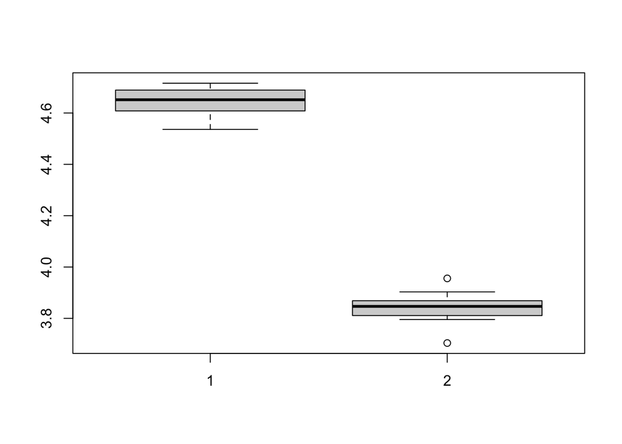

```r
eset = ExpressionSet(geneExpression,phenoData = pd,featureData = fd)
ind1 <- which(featureData(eset)$CHR == "chrY")
ind2 <- pData(eset)$group == 1
femaleY <- colMeans(exprs(eset)[ind1, ind2])
maleY <- colMeans(exprs(eset)[ind1, !ind2])
boxplot(maleY, femaleY)
```

```r
median_diff=median(maleY) - median(femaleY)

paste("Difference in median expression of genes on the Y chromosome between maleY and femaleY: ", median_diff)
```

```
## [1] "Difference in median expression of genes on the Y chromosome between maleY and femaleY:  0.804926455903774"
```

## Reading Microarray Raw Data: Single-Color Arrays

- loading microArray data into R: Affymetrix one-color arrays and Agilent two-color
- Affy package: parsers for reading in raw data files
- *cel* files are raw data
- *sample info* files have table describing each sample
- **pm** = perfect match probe-level intensities
- columns of probe-level data will match the rows of pData - each row represents a sample and column matches sample. Rownames **pData** match colnames **pm**
- Keep character which represents platform that the technology used
- Bioconductor has a package which matches gene IDs to meaningful terms
- Experiment data, sample information, third piece of information which connects us to other information which describes genes
- Last step: turn into gene-level information –> probe level. Algorithm **rma** implemented in Bioconductor to do this using quantile normalization and background correction.
- If only want gene expression data and not probe-level, you can use **justRMA** function to read and process in one shot

```r
wd <- getwd()
datadir <- paste0(wd, "/rawdata-master")    # downloaded files
basedir <- paste0(datadir, "/celfiles")
setwd(basedir)
library(affy)
tab <- read.delim("sampleinfo.txt",check.names=FALSE,as.is=TRUE)
rownames(tab) <- tab$filenames

tab
```

```
##                                       filenames 37777_at 684_at 1597_at
## 1521a99hpp_av06.CEL.gz   1521a99hpp_av06.CEL.gz     0.00   0.25     0.5
## 1532a99hpp_av04.CEL.gz   1532a99hpp_av04.CEL.gz     0.00   0.25     0.5
## 2353a99hpp_av08.CEL.gz   2353a99hpp_av08.CEL.gz     0.00   0.25     0.5
## 1521b99hpp_av06.CEL.gz   1521b99hpp_av06.CEL.gz     0.25   0.50     1.0
## 1532b99hpp_av04.CEL.gz   1532b99hpp_av04.CEL.gz     0.25   0.50     1.0
## 2353b99hpp_av08r.CEL.gz 2353b99hpp_av08r.CEL.gz     0.25   0.50     1.0
##                         38734_at 39058_at 36311_at 36889_at 1024_at 36202_at
## 1521a99hpp_av06.CEL.gz         1        2        4        8      16       32
## 1532a99hpp_av04.CEL.gz         1        2        4        8      16       32
## 2353a99hpp_av08.CEL.gz         1        2        4        8      16       32
## 1521b99hpp_av06.CEL.gz         2        4        8       16      32       64
## 1532b99hpp_av04.CEL.gz         2        4        8       16      32       64
## 2353b99hpp_av08r.CEL.gz        2        4        8       16      32       64
##                         36085_at 40322_at 407_at 1091_at 1708_at 33818_at
## 1521a99hpp_av06.CEL.gz        64      128   0.00     512    1024      256
## 1532a99hpp_av04.CEL.gz        64      128   0.00     512    1024      256
## 2353a99hpp_av08.CEL.gz        64      128   0.00     512    1024      256
## 1521b99hpp_av06.CEL.gz       128      256   0.25    1024       0      512
## 1532b99hpp_av04.CEL.gz       128      256   0.25    1024       0      512
## 2353b99hpp_av08r.CEL.gz      128      256   0.25    1024       0      512
##                         546_at
## 1521a99hpp_av06.CEL.gz      32
## 1532a99hpp_av04.CEL.gz      32
## 2353a99hpp_av08.CEL.gz      32
## 1521b99hpp_av06.CEL.gz      64
## 1532b99hpp_av04.CEL.gz      64
## 2353b99hpp_av08r.CEL.gz     64
```

```r
fns <- list.celfiles(basedir)
fns
```

```
## [1] "1521a99hpp_av06.CEL.gz"  "1521b99hpp_av06.CEL.gz"
## [3] "1532a99hpp_av04.CEL.gz"  "1532b99hpp_av04.CEL.gz"
## [5] "2353a99hpp_av08.CEL.gz"  "2353b99hpp_av08r.CEL.gz"
```

```r
fns %in% tab[,1] ##check
```

```
## [1] TRUE TRUE TRUE TRUE TRUE TRUE
```

```r
ab <- ReadAffy(phenoData=tab)

dim(pm(ab))
```

```
## [1] 201807      6
```

```r
dim(pData(ab))
```

```
## [1]  6 17
```

```r
rownames(ab)
```

```
##     [1] "100_g_at"                    "1000_at"
##     [3] "1001_at"                     "1002_f_at"
##     [5] "1003_s_at"                   "1004_at"
##     [7] "1005_at"                     "1006_at"
##     [9] "1007_s_at"                   "1008_f_at"
##    [11] "1009_at"                     "101_at"
##    [13] "1010_at"                     "1011_s_at"
##    [15] "1012_at"                     "1013_at"
##    [17] "1014_at"                     "1015_s_at"
##    [19] "1016_s_at"                   "1017_at"
##    [21] "1018_at"                     "1019_g_at"
##    [23] "102_at"                      "1020_s_at"
##    [25] "1021_at"                     "1022_f_at"
##    [27] "1023_at"                     "1024_at"
##    [29] "1025_g_at"                   "1026_s_at"
```

[output cut: 6298 more lines]

```r
colnames(pm(ab))
```

```
## [1] "1521a99hpp_av06.CEL.gz"  "1532a99hpp_av04.CEL.gz"
## [3] "2353a99hpp_av08.CEL.gz"  "1521b99hpp_av06.CEL.gz"
## [5] "1532b99hpp_av04.CEL.gz"  "2353b99hpp_av08r.CEL.gz"
```

```r
annotation(ab)
```

```
## [1] "hgu95a"
```

## Agilent two-color Arrays

- Package **limma** for two-color arrays
- Read in sample information - pairing of files to tell you what is red channel, what is green channel. Different scanners have different way of storing.
- **lima** format is described in documentation - **readTargets**
- **read.maimages** source which tells the package what imaging software was used to produce these files
- **MA.RG** stores the log ratio of red and green
- Function to look at images

```r
# datadir defined in previous video
library(limma)
```

```r
library(rafalib)
datadir <- paste0(wd, "/rawdata-master")    # downloaded files
basedir <- paste0(datadir, "/agilent")
setwd(basedir)
targets <- readTargets("TargetBeta7.txt")
RG <- read.maimages(targets$FileName, source="genepix")  # red and green 23k genes
```

```
## Read 6Hs.195.1.gpr
## Read 6Hs.168.gpr
## Read 6Hs.166.gpr
## Read 6Hs.187.1.gpr
## Read 6Hs.194.gpr
## Read 6Hs.243.1.gpr
```

```r
MA <- MA.RG(RG,bc.method="none")  # M and A, same information but transformed
dim(RG$R)
```

```
## [1] 23184     6
```

```r
dim(RG$G)
```

```
## [1] 23184     6
```

```r
dim(MA$M)
```

```
## [1] 23184     6
```

```r
dim(MA$A)
```

```
## [1] 23184     6
```

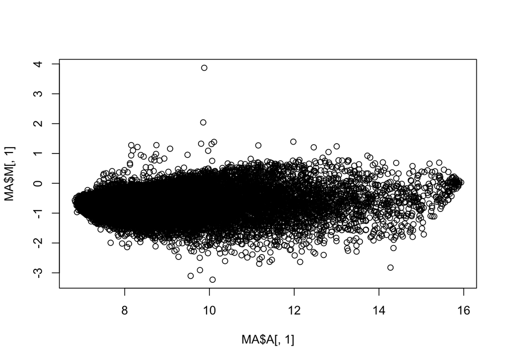

```r
plot(MA$A[,1], MA$M[,1])    # MA plot for first sample
```

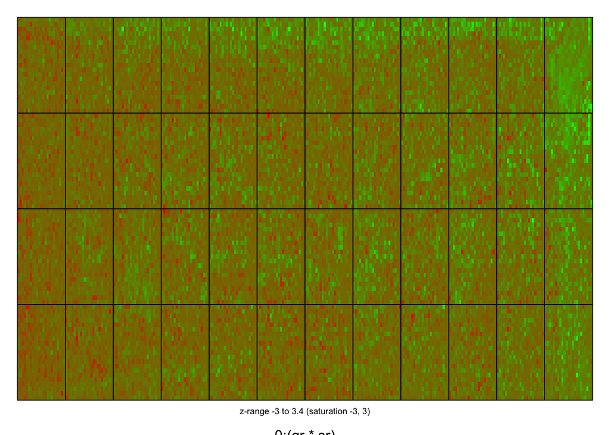

```r
# microarray image
mypar(1,1)
imageplot(MA$M[,2], RG$printer, zlim=c(-3,3))
```

```r
dev.off()
```

## Assessment: Reading microarray data

```r
library(hgu95acdf)

wd <- getwd()
datadir <- paste0(wd, "/rawdata-master")    # downloaded files
basedir <- paste0(datadir, "/celfiles")
setwd(basedir)
library(affy)
tab <- read.delim("sampleinfo.txt",check.names=FALSE,as.is=TRUE)
rownames(tab) <- tab$filenames

tab
```

```
##                                       filenames 37777_at 684_at 1597_at
## 1521a99hpp_av06.CEL.gz   1521a99hpp_av06.CEL.gz     0.00   0.25     0.5
## 1532a99hpp_av04.CEL.gz   1532a99hpp_av04.CEL.gz     0.00   0.25     0.5
## 2353a99hpp_av08.CEL.gz   2353a99hpp_av08.CEL.gz     0.00   0.25     0.5
## 1521b99hpp_av06.CEL.gz   1521b99hpp_av06.CEL.gz     0.25   0.50     1.0
## 1532b99hpp_av04.CEL.gz   1532b99hpp_av04.CEL.gz     0.25   0.50     1.0
## 2353b99hpp_av08r.CEL.gz 2353b99hpp_av08r.CEL.gz     0.25   0.50     1.0
##                         38734_at 39058_at 36311_at 36889_at 1024_at 36202_at
## 1521a99hpp_av06.CEL.gz         1        2        4        8      16       32
## 1532a99hpp_av04.CEL.gz         1        2        4        8      16       32
## 2353a99hpp_av08.CEL.gz         1        2        4        8      16       32
## 1521b99hpp_av06.CEL.gz         2        4        8       16      32       64
## 1532b99hpp_av04.CEL.gz         2        4        8       16      32       64
## 2353b99hpp_av08r.CEL.gz        2        4        8       16      32       64
##                         36085_at 40322_at 407_at 1091_at 1708_at 33818_at
## 1521a99hpp_av06.CEL.gz        64      128   0.00     512    1024      256
## 1532a99hpp_av04.CEL.gz        64      128   0.00     512    1024      256
## 2353a99hpp_av08.CEL.gz        64      128   0.00     512    1024      256
## 1521b99hpp_av06.CEL.gz       128      256   0.25    1024       0      512
## 1532b99hpp_av04.CEL.gz       128      256   0.25    1024       0      512
## 2353b99hpp_av08r.CEL.gz      128      256   0.25    1024       0      512
##                         546_at
## 1521a99hpp_av06.CEL.gz      32
## 1532a99hpp_av04.CEL.gz      32
## 2353a99hpp_av08.CEL.gz      32
## 1521b99hpp_av06.CEL.gz      64
## 1532b99hpp_av04.CEL.gz      64
## 2353b99hpp_av08r.CEL.gz     64
```

```r
level_gene_spike = tab[tab$filenames == "1521a99hpp_av06.CEL.gz", "36311_at"]
paste("level gene 36311_at spiked: ", level_gene_spike)
```

```
## [1] "level gene 36311_at spiked:  4"
```

```r
fns <- list.celfiles(basedir)

ab <- ReadAffy(phenoData=tab)

pn = probeNames(ab)
num_features_associated_w_gene=length(pn[pn == "36311_at"])

paste("number of features associated with gene 36311_at: ", num_features_associated_w_gene)
```

```
## [1] "number of features associated with gene 36311_at:  16"
```

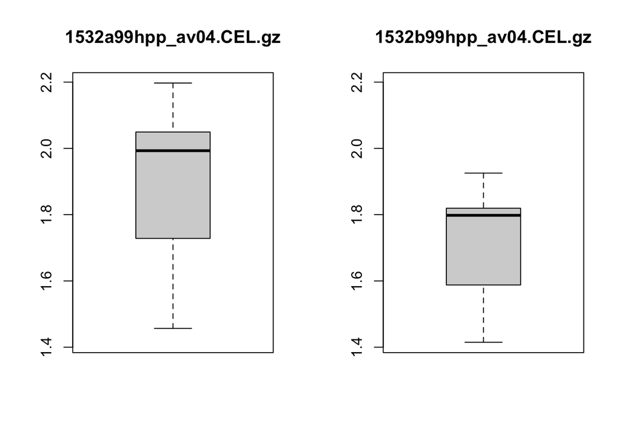

```r
ab_sub <- ab[,ab$filenames %in% c("1532a99hpp_av04.CEL.gz", "1532b99hpp_av04.CEL.gz")]

probe_level_intensities = pm(ab_sub)
probeset_ids = which(pn == "36085_at")
probe_level_intensities_at_probeset = probe_level_intensities[probeset_ids,]

sample_metadata = pData(ab_sub)

par(mfrow=c(1, 2))
r_1 = log2(probe_level_intensities_at_probeset[,"1532a99hpp_av04.CEL.gz"]) / log2(sample_metadata[ "1532a99hpp_av04.CEL.gz", "36085_at"])
r_2 = log2(probe_level_intensities_at_probeset[,"1532b99hpp_av04.CEL.gz"]) / log2(sample_metadata[ "1532b99hpp_av04.CEL.gz", "36085_at"])
lmts <- range(r_1, r_2)
boxplot(r_1, main="1532a99hpp_av04.CEL.gz", ylim=lmts)
boxplot(r_2, main="1532b99hpp_av04.CEL.gz", ylim=lmts)
```

## SummarizedExperiment class

- Similar to ExpressionSets but preferred for sequencing-based data
- Accomodates experiments where genomic location is important
- Most commonly used for NGS
- **assay** function to access counts
- **colData** equivalent to **pData** on ExpressionSet
- rows correspond to genes - collections of exons (GRanges list used to count RNA sequencing reads)
- **metadata** how GRanges List was constructed and from what database etc.
- **MIAME** minimal information about microarray experiment

```r
library(parathyroidSE)
data(parathyroidGenesSE)
se <- parathyroidGenesSE
se
```

```
## class: RangedSummarizedExperiment
## dim: 63193 27
## metadata(1): MIAME
## assays(1): counts
## rownames(63193): ENSG00000000003 ENSG00000000005 ... LRG_98 LRG_99
## rowData names(0):
## colnames: NULL
## colData names(8): run experiment ... study sample
```

```r
# assay contains results of the assay
dim(se)
```

```
## [1] 63193    27
```

```r
assay(se)[1:3,1:3]
```

```
##                 [,1] [,2] [,3]
## ENSG00000000003  792 1064  444
## ENSG00000000005    4    1    2
## ENSG00000000419  294  282  164
```

```r
dim(assay(se))    # rows = features (ranges), columns = samples
```

```
## [1] 63193    27
```

```r
# colData contains sample information
colData(se)[1:3,1:6]
```

```
## DataFrame with 3 rows and 6 columns
##           run experiment  patient treatment     time submission
##   <character>   <factor> <factor>  <factor> <factor>   <factor>
## 1   SRR479052  SRX140503        1   Control      24h  SRA051611
## 2   SRR479053  SRX140504        1   Control      48h  SRA051611
## 3   SRR479054  SRX140505        1   DPN          24h  SRA051611
```

```r
dim(colData(se))
```

```
## [1] 27  8
```

```r
names(colData(se))
```

```
## [1] "run"        "experiment" "patient"    "treatment"  "time"
## [6] "submission" "study"      "sample"
```

```r
colData(se)$treatment
```

```
##  [1] Control Control DPN     DPN     OHT     OHT     Control Control DPN
## [10] DPN     DPN     OHT     OHT     OHT     Control Control DPN     DPN
## [19] OHT     OHT     Control DPN     DPN     DPN     OHT     OHT     OHT
## Levels: Control DPN OHT
```

```r
as.numeric(colData(se)$treatment)
```

```
##  [1] 1 1 2 2 3 3 1 1 2 2 2 3 3 3 1 1 2 2 3 3 1 2 2 2 3 3 3
```

```r
# rowRanges contains feature information
rowRanges(se)[1]
```

```
## GRangesList object of length 1:
## $ENSG00000000003
## GRanges object with 17 ranges and 2 metadata columns:
##        seqnames            ranges strand |   exon_id       exon_name
##           <Rle>         <IRanges>  <Rle> | <integer>     <character>
##    [1]        X 99883667-99884983      - |    664095 ENSE00001459322
##    [2]        X 99885756-99885863      - |    664096 ENSE00000868868
##    [3]        X 99887482-99887565      - |    664097 ENSE00000401072
##    [4]        X 99887538-99887565      - |    664098 ENSE00001849132
##    [5]        X 99888402-99888536      - |    664099 ENSE00003554016
##    ...      ...               ...    ... .       ...             ...
##   [13]        X 99890555-99890743      - |    664106 ENSE00003512331
##   [14]        X 99891188-99891686      - |    664108 ENSE00001886883
##   [15]        X 99891605-99891803      - |    664109 ENSE00001855382
##   [16]        X 99891790-99892101      - |    664110 ENSE00001863395
##   [17]        X 99894942-99894988      - |    664111 ENSE00001828996
##   -------
##   seqinfo: 580 sequences (1 circular) from an unspecified genome
```

```r
class(rowRanges(se))
```

```
## [1] "CompressedGRangesList"
## attr(,"package")
## [1] "GenomicRanges"
```

```r
length(rowRanges(se))    # number of genes
```

```
## [1] 63193
```

```r
length(rowRanges(se)[[1]])    # number of exons for first gene
```

```
## [1] 17
```

```r
head(rownames(se))
```

```
## [1] "ENSG00000000003" "ENSG00000000005" "ENSG00000000419" "ENSG00000000457"
## [5] "ENSG00000000460" "ENSG00000000938"
```

```r
metadata(rowRanges(se))
```

```
## $genomeInfo
## $genomeInfo$`Db type`
## [1] "TranscriptDb"
##
## $genomeInfo$`Supporting package`
## [1] "GenomicFeatures"
##
## $genomeInfo$`Data source`
## [1] "BioMart"
##
## $genomeInfo$Organism
## [1] "Homo sapiens"
##
## $genomeInfo$`Resource URL`
## [1] "www.biomart.org:80"
##
## $genomeInfo$`BioMart database`
## [1] "ensembl"
##
## $genomeInfo$`BioMart database version`
## [1] "ENSEMBL GENES 72 (SANGER UK)"
##
## $genomeInfo$`BioMart dataset`
## [1] "hsapiens_gene_ensembl"
##
## $genomeInfo$`BioMart dataset description`
## [1] "Homo sapiens genes (GRCh37.p11)"
##
## $genomeInfo$`BioMart dataset version`
## [1] "GRCh37.p11"
##
## $genomeInfo$`Full dataset`
## [1] "yes"
##
## $genomeInfo$`miRBase build ID`
## [1] NA
##
## $genomeInfo$transcript_nrow
## [1] "213140"
##
## $genomeInfo$exon_nrow
## [1] "737783"
##
## $genomeInfo$cds_nrow
## [1] "531154"
##
## $genomeInfo$`Db created by`
## [1] "GenomicFeatures package from Bioconductor"
##
## $genomeInfo$`Creation time`
## [1] "2013-07-30 17:30:25 +0200 (Tue, 30 Jul 2013)"
##
## $genomeInfo$`GenomicFeatures version at creation time`
## [1] "1.13.21"
##
## $genomeInfo$`RSQLite version at creation time`
## [1] "0.11.4"
##
## $genomeInfo$DBSCHEMAVERSION
## [1] "1.0"
```

```r
# additional metadata, including sample information
metadata(se)$MIAME
```

```
## Experiment data
##   Experimenter name: Felix Haglund
##   Laboratory: Science for Life Laboratory Stockholm
##   Contact information: Mikael Huss
##   Title: DPN and Tamoxifen treatments of parathyroid adenoma cells
##   URL: http://www.ncbi.nlm.nih.gov/geo/query/acc.cgi?acc=GSE37211
##   PMIDs: 23024189
##
##   Abstract: A 251 word abstract is available. Use 'abstract' method.
```

```r
#abstract(metadata(se)$MIAME)
```

## Assessment: SummarizedExperiment

```r
library(airway)
data(airway)
metadata(airway)
```

```
## [[1]]
## Experiment data
##   Experimenter name: Himes BE
##   Laboratory: NA
##   Contact information:
##   Title: RNA-Seq transcriptome profiling identifies CRISPLD2 as a glucocorticoid responsive gene that modulates cytokine function in airway smooth muscle cells.
##   URL: http://www.ncbi.nlm.nih.gov/pubmed/24926665
##   PMIDs: 24926665
##
##   Abstract: A 226 word abstract is available. Use 'abstract' method.
```

```r
dim(airway)
```

```
## [1] 64102     8
```

```r
sample_metadata <- colData(airway)
sample_cell_line = sample_metadata["SRR1039509","cell"]
paste("Cell line associated with sample: ", sample_cell_line)
```

```
## [1] "Cell line associated with sample:  N61311"
```

```r
index_min = which.min(sample_metadata$avgLength)
sample_name <- rownames(sample_metadata[index_min,])
paste("Sample with shortest average read length: ", sample_name)
```

```
## [1] "Sample with shortest average read length:  SRR1039513"
```

```r
num_genes=length(rowRanges(airway))
paste("number of genes in dataset: ", num_genes)
```

```
## [1] "number of genes in dataset:  64102"
```

```r
g100_md <- rowRanges(airway)[[100]]
num_exons_g100 <- length(g100_md)
paste("number of exons at 100th gene: ", num_exons_g100)
```

```
## [1] "number of exons at 100th gene:  55"
```

```r
total_bp_long_including_introns <- sum(width(range(g100_md)))
paste("number of bases long of 100th gene (including introns): ", total_bp_long_including_introns)
```

```
## [1] "number of bases long of 100th gene (including introns):  78739"
```

```r
tssgr <- resize(range(rowRanges(airway)[[100]]), 1)
tss <- start(tssgr)
paste("transcription start site of 100th gene: ", tss)
```

```
## [1] "transcription start site of 100th gene:  87109751"
```

```r
expr <- assay(airway)["ENSG00000103196",]
mean_expr <- mean(expr)
paste("mean expression of ENSG00000103196 across all samples: ", mean_expr)
```

```
## [1] "mean expression of ENSG00000103196 across all samples:  2865.625"
```

```r
samples_treated_w_dex <- rownames(sample_metadata[which(sample_metadata$dex == "trt"),])
expr_treated <- subset(expr, names(expr) %in% samples_treated_w_dex)
mean_expr_treated <- mean(expr_treated)
paste("mean expression of ENSG00000103196 across all samples treated with dex: ", mean_expr_treated)
```

```
## [1] "mean expression of ENSG00000103196 across all samples treated with dex:  4842.75"
```

```r
expr_untreated <- subset(expr, !names(expr) %in% samples_treated_w_dex)
mean_expr_untreated <- mean(expr_untreated)
paste("mean expression of ENSG00000103196 across all samples not treated with dex: ", mean_expr_untreated)
```

```
## [1] "mean expression of ENSG00000103196 across all samples not treated with dex:  888.5"
```

```r
log_ratio_trt_untrt <- log2(mean_expr_treated / mean_expr_untreated)
paste("log ratio of mean expression between treated and untreated: ", log_ratio_trt_untrt)
```

```
## [1] "log ratio of mean expression between treated and untreated:  2.44638284643983"
```

## Importing NGS data in R

- Two main Bioconductor packages for working with NGS data:
  - **Rsamtools** - low-level functions for reading and parsing raw NGS stored in standard formats. Interface to samtools (implemented in C)
  - **GenomicAlignments** - high-level functions and classes for reading and organizing NGS data as bioconductor objects
- BAM files - compressed format of SAM. Contains information about alignment of NGS reads to reference genome. Producted by alignment software which takes: fastq files, genomic index created from reference genome.
- Alignment software is application specific - i.e. RNA-seq programs different from genomic DNA sequencing

### How to import NGS data using Rsamtools

Example from pasillaBamSubset package

```r
library(pasillaBamSubset)
library(Rsamtools)
filename <- untreated1_chr4()
# create bamfile object which allows other functions to know how to process
bf <- BamFile(filename) # information about chromosomes which are declared in header of the BAM file
seqinfo(bf)
```

```
## Seqinfo object with 8 sequences from an unspecified genome:
##   seqnames seqlengths isCircular genome
##   chr2L      23011544         NA   <NA>
##   chr2R      21146708         NA   <NA>
##   chr3L      24543557         NA   <NA>
##   chr3R      27905053         NA   <NA>
##   chr4        1351857         NA   <NA>
##   chrM          19517         NA   <NA>
##   chrX       22422827         NA   <NA>
##   chrYHet      347038         NA   <NA>
```

```r
s1 <- seqlengths(bf)

quickBamFlagSummary(bf)  # summary of the kind of alignments in the file
```

```
##                                 group |    nb of |    nb of | mean / max
##                                    of |  records |   unique | records per
##                               records | in group |   QNAMEs | unique QNAME
## All records........................ A |   204355 |   190770 | 1.07 / 10
##   o template has single segment.... S |   204355 |   190770 | 1.07 / 10
##   o template has multiple segments. M |        0 |        0 |   NA / NA
##       - first segment.............. F |        0 |        0 |   NA / NA
##       - last segment............... L |        0 |        0 |   NA / NA
##       - other segment.............. O |        0 |        0 |   NA / NA
##
## Note that (S, M) is a partitioning of A, and (F, L, O) is a partitioning of M.
## Indentation reflects this.
##
## Details for group S:
##   o record is mapped.............. S1 |   204355 |   190770 | 1.07 / 10
##       - primary alignment......... S2 |   204355 |   190770 | 1.07 / 10
##       - secondary alignment....... S3 |        0 |        0 |   NA / NA
##   o record is unmapped............ S4 |        0 |        0 |   NA / NA
```

### Specifying: what and which

- Number of functions in Rsamtools take argument param which expects **ScanBamParam** specification
- Two important options:
  - what - what kind of information to extract
  - which - which ranges of alignments to extract?
- BAM files often paired with index file to quickly pull out info about reads from a particular genomic range

```r
# count the number of records (reads) on chromosome 4:
gr <- GRanges("chr4", IRanges(1, s1["chr4"]))
countBam(bf, param = ScanBamParam(which=gr))
```

```
##   space start     end   width                file records nucleotides
## 1  chr4     1 1351857 1351857 untreated1_chr4.bam  204355    15326625
```

```r
reads <- scanBam(BamFile(filename, yieldSize = 5))  # limit number of reads which will be extracted to 5 at a time. Each time we call scanBam we will get 5 more reads until there are no more
```

### Examining the output of scanBam

- **reads** object is a list of lists - outer list indexes over the ranges in the which command. Inner list contains info from the bam file - since we didn’t specify what we get everything

```r
class(reads)
```

```
## [1] "list"
```

```r
names(reads[[1]])
```

```
##  [1] "qname"  "flag"   "rname"  "strand" "pos"    "qwidth" "mapq"   "cigar"
##  [9] "mrnm"   "mpos"   "isize"  "seq"    "qual"
```

```r
reads[[1]]$pos # aligned start position
```

```
## [1] 892 919 924 936 949
```

```r
reads[[1]]$rname # chromosome
```

```
## [1] chr4 chr4 chr4 chr4 chr4
## Levels: chr2L chr2R chr3L chr3R chr4 chrM chrX chrYHet
```

```r
reads[[1]]$strand # the strand
```

```
## [1] - - + + +
## Levels: + - *
```

```r
reads[[1]]$qwidth # the width of the read
```

```
## [1] 75 75 75 75 75
```

```r
reads[[1]]$seq # the sequence of the read
```

```
## DNAStringSet object of length 5:
##     width seq
## [1]    75 CTGTGGTGACCAACACCACAGAATGGTTCGGGCC...GGGTTCCCTGCCCCTTTCCTGGCTAGGTTGTCC
## [2]    75 TCGGGCCCAATTAGAGGGTTCCCTGCCCCTTTCC...TTGTCCGCTAGCTCATTTCCTGGGCTGTTGTTG
## [3]    75 CCCAATTAGAGGATTCTCTGCCCCTTTCCTGGCT...CGGTAGCTCATTTCCCGGGATGTTGTTGTGTCC
## [4]    75 GTTCTCTGCCCCTTTCCTGGCTAGGTTGTCCGCT...TCCCGAGATGTTGTTGTGTCCCGGGACCCACCT
## [5]    75 TTCCTGGCTAGGTTGTCCGCTAGCTCATTTCCCG...TTGTGTCCCGGGACACACCTTATTGTGAGTTTG
```

```r
# Example specifying what and which to specify what parameters to extract over which ranges

gr <- GRanges("chr4", IRanges(500000, 700000))
reads <- scanBam(bf, params = ScanBamParam(what=c("pos", "strand"), which=gr))
```

### GenomicAlignments package

- Containers for storing and manipulating short genomic alignments. Counting, computing coverage, junction detection, working with nucleotide content of the alignments
- Two most important functions in **GenomicAlignments** are:
  - **readGAlignments()** - read data from BAM files
  - **summarizeOverlaps()** - simplifies counting reads in genomic ranges across one or more files

```r
library(GenomicAlignments)
ga <- readGAlignments(bf)
length(ga)
```

```
## [1] 204355
```

```r
granges(ga[1]) # extract GRanges object within GAlignments object
```

```
## GRanges object with 1 range and 0 metadata columns:
##       seqnames    ranges strand
##          <Rle> <IRanges>  <Rle>
##   [1]     chr4   892-966      -
##   -------
##   seqinfo: 8 sequences from an unspecified genome
```

```r
# GenomicRanges functions that work on GAlignments

gr <- GRanges("chr4", IRanges(700000, 800000))
(fo <- findOverlaps(ga, gr))
```

```
## Hits object with 6465 hits and 0 metadata columns:
##          queryHits subjectHits
##          <integer>   <integer>
##      [1]    127157           1
##      [2]    127238           1
##      [3]    127240           1
##      [4]    127242           1
##      [5]    127243           1
##      ...       ...         ...
##   [6461]    144660           1
##   [6462]    144661           1
##   [6463]    144662           1
##   [6464]    144663           1
##   [6465]    144664           1
##   -------
##   queryLength: 204355 / subjectLength: 1
```

```r
countOverlaps(gr, ga)
```

```
## [1] 6465
```

```r
table(ga %over% gr)
```

```
##
##  FALSE   TRUE
## 197890   6465
```

## Assessment: Importing NGS data

- pasillaBamSubset package - BAM file containing a subset of reads from single-end RNA-seq experiment in fruit fly, aligning to chromosome 4

```r
library(pasillaBamSubset)
library(Rsamtools)
filename <- untreated1_chr4()
bf <- BamFile(filename)
gr <- GRanges("chr4", IRanges(440000, 470000))
num_read_aligns <- countBam(bf, param = ScanBamParam(which=gr))["records"]
paste("number of read aligns between chromosomes 440k - 470k: ", num_read_aligns)
```

```
## [1] "number of read aligns between chromosomes 440k - 470k:  1665"
```

```r
rs_dna_string_set <- scanBam(bf, params = ScanBamParam(what="seq", which=gr))
seq_data <- rs_dna_string_set[[1]]$seq
gc_content <- (vcountPattern("C", seq_data) + vcountPattern("G", seq_data)) / width(seq_data)
mean_gc_content <- mean(gc_content)
paste("average proportion of reads which align to chromosome 4 between positions 440k and 470k: ", mean_gc_content)
```

```
## [1] "average proportion of reads which align to chromosome 4 between positions 440k and 470k:  0.428009819513428"
```

```r
mean(letterFrequency(seq_data, "GC", as.prob=TRUE))
```

```
## [1] 0.4280098
```

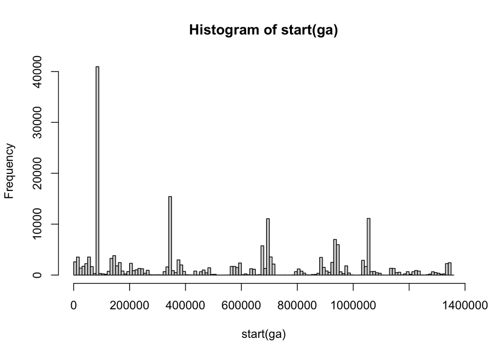

```r
library(GenomicAlignments)
ga <- readGAlignments(BamFile(filename))
hist(start(ga), breaks=100)  # genes are spread out on the chromosome
```

```r
library(TxDb.Dmelanogaster.UCSC.dm3.ensGene)
g <- genes(TxDb.Dmelanogaster.UCSC.dm3.ensGene)    # GRanges corresponding to genes

g2 <- g[g %over% GRanges("chr4", IRanges(200000, 300000))]

num_overlaps <- sum(countOverlaps(ga, g2["FBgn0039890"]))
paste("negative strand reads overlapping the FBgn0039890 gene: ", num_overlaps)
```

```
## [1] "negative strand reads overlapping the FBgn0039890 gene:  1085"
```

## Creating a count table from a BAM file

- How to count sequencing reads which fall into genomic features
- End up with summarized experiment object - count matrix with rows corresponding to genomic ranges and columns corresponding to different samples
- Mapped to DM3 genome
- If can’t find transcript database you are interested in you can use the makeTranscriptDbFromGFF file function
- Files contain transcripts and exons which make up the gene

```r
library(pasillaBamSubset)
library(TxDb.Dmelanogaster.UCSC.dm3.ensGene) # transcript database
txdb <- TxDb.Dmelanogaster.UCSC.dm3.ensGene
gr1 <- exonsBy(txdb, by="gene") # for each gene, pull out the exons
gr1[100] # GRangesList of exons for 100th gene
```

```
## GRangesList object of length 1:
## $FBgn0000286
## GRanges object with 8 ranges and 2 metadata columns:
##       seqnames          ranges strand |   exon_id   exon_name
##          <Rle>       <IRanges>  <Rle> | <integer> <character>
##   [1]    chr2L 4876890-4879196      - |      8515        <NA>
##   [2]    chr2L 4877289-4879196      - |      8516        <NA>
##   [3]    chr2L 4880294-4880472      - |      8517        <NA>
##   [4]    chr2L 4880378-4880472      - |      8518        <NA>
##   [5]    chr2L 4881215-4882492      - |      8519        <NA>
##   [6]    chr2L 4882865-4883113      - |      8520        <NA>
##   [7]    chr2L 4882889-4883113      - |      8521        <NA>
##   [8]    chr2L 4882889-4883341      - |      8522        <NA>
##   -------
##   seqinfo: 15 sequences (1 circular) from dm3 genome
```

```r
gr1[[100]] # GRanges with exons of 100th gene
```

```
## GRanges object with 8 ranges and 2 metadata columns:
##       seqnames          ranges strand |   exon_id   exon_name
##          <Rle>       <IRanges>  <Rle> | <integer> <character>
##   [1]    chr2L 4876890-4879196      - |      8515        <NA>
##   [2]    chr2L 4877289-4879196      - |      8516        <NA>
##   [3]    chr2L 4880294-4880472      - |      8517        <NA>
##   [4]    chr2L 4880378-4880472      - |      8518        <NA>
##   [5]    chr2L 4881215-4882492      - |      8519        <NA>
##   [6]    chr2L 4882865-4883113      - |      8520        <NA>
##   [7]    chr2L 4882889-4883113      - |      8521        <NA>
##   [8]    chr2L 4882889-4883341      - |      8522        <NA>
##   -------
##   seqinfo: 15 sequences (1 circular) from dm3 genome
```

```r
gr1[[100]][1] # first exon of 100th gene
```

```
## GRanges object with 1 range and 2 metadata columns:
##       seqnames          ranges strand |   exon_id   exon_name
##          <Rle>       <IRanges>  <Rle> | <integer> <character>
##   [1]    chr2L 4876890-4879196      - |      8515        <NA>
##   -------
##   seqinfo: 15 sequences (1 circular) from dm3 genome
```

```r
# paths to BAM files
fl1 <- untreated1_chr4()
fl2 <- untreated3_chr4()

library(Rsamtools)
library(GenomicRanges)
library(GenomicAlignments)

# specify files with BamFileList - container for two files
fls <- BamFileList(c(fl1, fl2)) # can specify yieldSize for number of reads
names(fls) <- c("first", "second")

# find reads that overlap exons. Different counting modes possible
# inter.feature: if read overlaps multiple features, it should not be counted which is the default
# singleEnd: files have single-end reads instead of paired-end reads
# fragments: if you are counting reads in paired end, you also want to count where only one of two reads in a pair aligns
so1 <- summarizeOverlaps(features=gr1, reads=fls, ignore.strand=TRUE)
so1
```

```
## class: RangedSummarizedExperiment
## dim: 15682 2
## metadata(0):
## assays(1): counts
## rownames(15682): FBgn0000003 FBgn0000008 ... FBgn0264726 FBgn0264727
## rowData names(0):
## colnames(2): first second
## colData names(0):
```

```r
# examine count matrix - assay functions pulls the first matrix from the assay slot
head(assay(so1))
```

```
##             first second
## FBgn0000003     0      0
## FBgn0000008     0      0
## FBgn0000014     0      0
## FBgn0000015     0      0
## FBgn0000017     0      0
## FBgn0000018     0      0
```

```r
colSums(assay(so1))  # number of reads which align uniquely to these features
```

```
##  first second
## 156469 122872
```

```r
# examine rest of the SummarizedExperiment components
rowRanges(so1)
```

```
## GRangesList object of length 15682:
## $FBgn0000003
## GRanges object with 1 range and 2 metadata columns:
##       seqnames          ranges strand |   exon_id   exon_name
##          <Rle>       <IRanges>  <Rle> | <integer> <character>
##   [1]    chr3R 2648220-2648518      + |     45123        <NA>
##   -------
##   seqinfo: 15 sequences (1 circular) from dm3 genome
##
## $FBgn0000008
## GRanges object with 13 ranges and 2 metadata columns:
##        seqnames            ranges strand |   exon_id   exon_name
##           <Rle>         <IRanges>  <Rle> | <integer> <character>
##    [1]    chr2R 18024494-18024531      + |     20314        <NA>
##    [2]    chr2R 18024496-18024713      + |     20315        <NA>
##    [3]    chr2R 18024938-18025756      + |     20316        <NA>
##    [4]    chr2R 18025505-18025756      + |     20317        <NA>
##    [5]    chr2R 18039159-18039200      + |     20322        <NA>
##    ...      ...               ...    ... .       ...         ...
##    [9]    chr2R 18058283-18059490      + |     20326        <NA>
##   [10]    chr2R 18059587-18059757      + |     20327        <NA>
##   [11]    chr2R 18059821-18059938      + |     20328        <NA>
##   [12]    chr2R 18060002-18060339      + |     20329        <NA>
##   [13]    chr2R 18060002-18060346      + |     20330        <NA>
##   -------
##   seqinfo: 15 sequences (1 circular) from dm3 genome
##
## ...
## <15680 more elements>
```

```r
colData(so1)
```

```
## DataFrame with 2 rows and 0 columns
```

```r
colData(so1)$sample <- c("one", "two")
colData(so1)
```

```
## DataFrame with 2 rows and 1 column
##             sample
##        <character>
## first          one
## second         two
```

```r
metadata(rowRanges(so1))
```

```
## $genomeInfo
## $genomeInfo$`Db type`
## [1] "TxDb"
##
## $genomeInfo$`Supporting package`
## [1] "GenomicFeatures"
##
## $genomeInfo$`Data source`
## [1] "UCSC"
##
## $genomeInfo$Genome
## [1] "dm3"
##
## $genomeInfo$Organism
## [1] "Drosophila melanogaster"
##
## $genomeInfo$`Taxonomy ID`
## [1] "7227"
##
## $genomeInfo$`UCSC Table`
## [1] "ensGene"
##
## $genomeInfo$`Resource URL`
## [1] "http://genome.ucsc.edu/"
##
## $genomeInfo$`Type of Gene ID`
## [1] "Ensembl gene ID"
##
## $genomeInfo$`Full dataset`
## [1] "yes"
##
## $genomeInfo$`miRBase build ID`
## [1] NA
##
## $genomeInfo$transcript_nrow
## [1] "29173"
##
## $genomeInfo$exon_nrow
## [1] "76920"
##
## $genomeInfo$cds_nrow
## [1] "62135"
##
## $genomeInfo$`Db created by`
## [1] "GenomicFeatures package from Bioconductor"
##
## $genomeInfo$`Creation time`
## [1] "2015-10-07 18:15:53 +0000 (Wed, 07 Oct 2015)"
##
## $genomeInfo$`GenomicFeatures version at creation time`
## [1] "1.21.30"
##
## $genomeInfo$`RSQLite version at creation time`
## [1] "1.0.0"
##
## $genomeInfo$DBSCHEMAVERSION
## [1] "1.1"
```

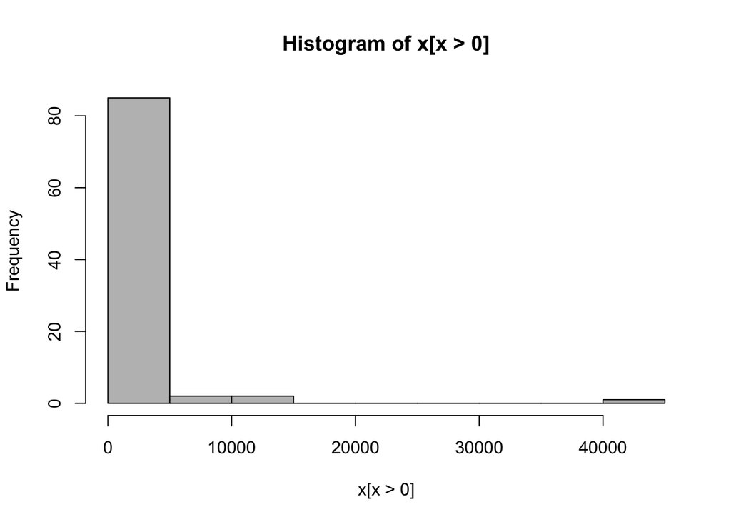

```r
# exploratory data analysis of counts
x <- assay(so1)[,1]
hist(x[x > 0], col="grey")
```

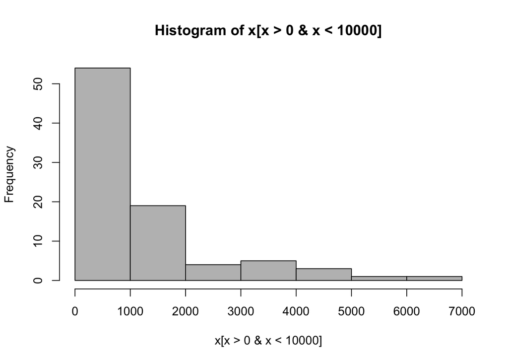

```r
hist(x[x > 0 & x < 10000], col="grey")
```

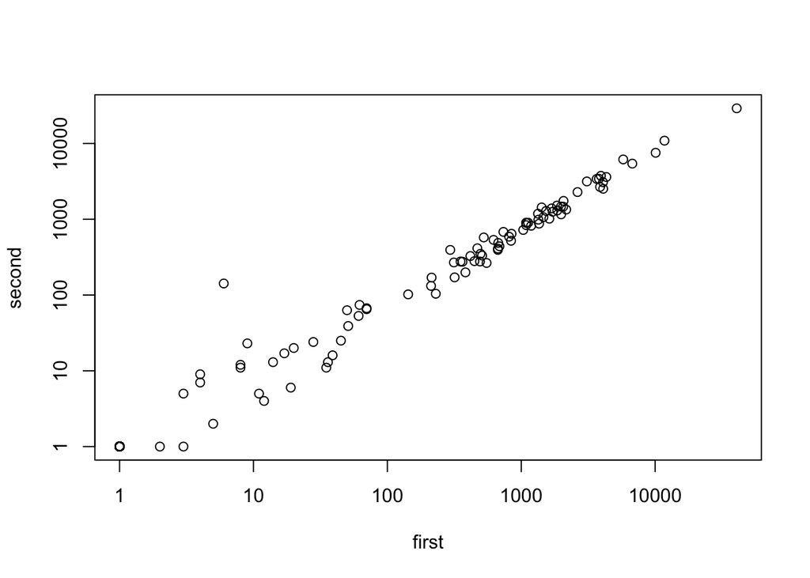

```r
plot(assay(so1) + 1, log="xy")  # highly correlated samples
```

```r
# count second file as paired-end reads

fls <- BamFileList(fl2)
so2 <- summarizeOverlaps(features=gr1,
                         reads=fls,
                         ignore.strand=TRUE,
                         singleEnd=FALSE,
                         fragments=TRUE
                         )
colSums(assay(so2))
```

```
## untreated3_chr4.bam
##               65591
```

```r
colSums(assay(so1))
```

```
##  first second
## 156469 122872
```

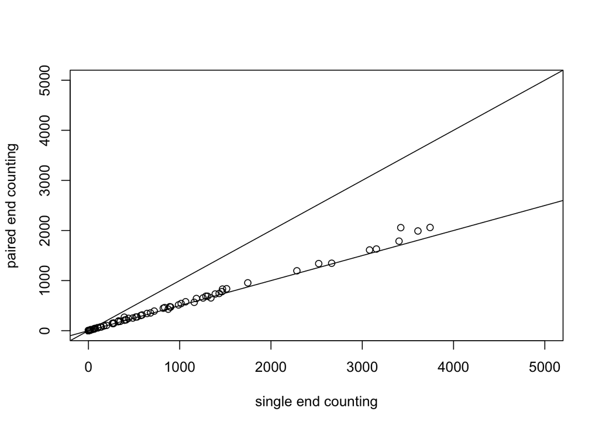

```r
plot(assay(so1)[,2], assay(so2)[,1], xlim=c(0,5000), ylim=c(0,5000),
     xlab="single end counting", ylab="paired end counting")
abline(0,1)
abline(0,0.5)
```

- rowData - information about the genes
- colData: information about the samples
- metadata on the features (rowData) - how the rowData was generated

## Assessment: Count table creation

```r
library(pasillaBamSubset)
library(TxDb.Dmelanogaster.UCSC.dm3.ensGene)
txdb <- TxDb.Dmelanogaster.UCSC.dm3.ensGene

g <- genes(txdb)
g <- g[seqnames(g) == "chr4"]

grl <- exonsBy(txdb, by="gene")
grl <- grl[names(g)]

all.equal(names(g), names(grl))
```

```
## [1] TRUE
```

```r
library(Rsamtools)
bf <- BamFile(untreated1_chr4())

library(GenomicAlignments)
g_sum <- summarizeOverlaps(features=g,
                           reads=bf,
                           ignore.strand=TRUE)
grl_sum <- summarizeOverlaps(features=grl,
                             reads=bf,
                             ignore.strand=TRUE
                             )

g_idx_nonzero = which(assay(g_sum) != 0)

prop_nonzero <- assay(grl_sum)[g_idx_nonzero] / assay(g_sum)[g_idx_nonzero]
avg_prop <- mean(prop_nonzero)
paste("mean ratio of counts in grl and g after removing zero counts: ", avg_prop)
```

```
## [1] "mean ratio of counts in grl and g after removing zero counts:  0.892927311957452"
```

```r
assay_data <- (assay(grl_sum) / sum(assay(grl_sum)))* 1000000
fpm_gene_chr4 <- assay_data["FBgn0002521",]
paste("FPM for the first gene FBgn0002521: ", fpm_gene_chr4)
```

```
## [1] "FPM for the first gene FBgn0002521:  4275.60730879599"
```

```r
ebp <- sum(width(reduce(grl)))
count <- assay(grl_sum)
fpm <- (count / sum(count)) * 1e6
fpkm <- (fpm / ebp) * 1e3
fpkm[1]
```

```
## [1] 1782.246
```

## The GEOquery package: ExpressionSets from NCBI’s repository

- Institutional archives of microarrays
- NCBI example: 17k gene expression assay platforms, 90k series, 4k datasets, 2.2mil samples
- GEOmetadb - 6 gB SQLite database. Tool for local investigation of whole GEO contents
- Pull desired experiment into R session with GEOquery
- treated with and cell type are basic experimental factors (treatment vs. control)

```r
library(GEOquery)
#glioMA = getGEO("GSE78703")[[1]]
#glioMA

#names(pData(glioMA))
#glioMA$molecule_ch1
#table(glioMA$`treated with:ch1`, glioMA$`cell type:ch1`)
```

## Platform-Oriented annotation

- GPL information page at GEO - 892 pages of platforms that have been identified
- 17k different platforms
- Most popular: Affymetrix human genome - 4760 series
- Interrogate probeset information with GEO - used to record expression values
- 1007_s_at interrogates gene DDR1 or certain microRNA - both occupy same cytoband so it is possible that you could use this probe
- Affymetrix oligo nucleotide probes deal with probe sets - each probe set is comprised of 25 mers
- Placed in different locations so that spatial artifacts on the array may be localized to one or another probe
- Robust to local spatial artifacts
- Info about geometry of chip, locations, contents of oligonucleotides with hgu133plus2probe package
- Most Affymetrix platforms have the probe packages in Bioconductor
  - used to study CG content of oligos, identify structural artifacts of CG content on probe intensity

```r
library(hgu133plus2.db)
hgu133plus2.db
```

```
## ChipDb object:
## | DBSCHEMAVERSION: 2.1
## | Db type: ChipDb
## | Supporting package: AnnotationDbi
## | DBSCHEMA: HUMANCHIP_DB
## | ORGANISM: Homo sapiens
## | SPECIES: Human
## | MANUFACTURER: Affymetrix
## | CHIPNAME: Human Genome U133 Plus 2.0 Array
## | MANUFACTURERURL: http://www.affymetrix.com/support/technical/byproduct.affx?product=hg-u133-plus
## | EGSOURCEDATE: 2015-Sep27
## | EGSOURCENAME: Entrez Gene
## | EGSOURCEURL: ftp://ftp.ncbi.nlm.nih.gov/gene/DATA
## | CENTRALID: ENTREZID
## | TAXID: 9606
## | GOSOURCENAME: Gene Ontology
## | GOSOURCEURL: ftp://ftp.geneontology.org/pub/go/godatabase/archive/latest-lite/
## | GOSOURCEDATE: 20150919
## | GOEGSOURCEDATE: 2015-Sep27
## | GOEGSOURCENAME: Entrez Gene
## | GOEGSOURCEURL: ftp://ftp.ncbi.nlm.nih.gov/gene/DATA
## | KEGGSOURCENAME: KEGG GENOME
## | KEGGSOURCEURL: ftp://ftp.genome.jp/pub/kegg/genomes
## | KEGGSOURCEDATE: 2011-Mar15
## | GPSOURCENAME: UCSC Genome Bioinformatics (Homo sapiens)
## | GPSOURCEURL: ftp://hgdownload.cse.ucsc.edu/goldenPath/hg19
## | GPSOURCEDATE: 2010-Mar22
## | ENSOURCEDATE: 2015-Jul16
## | ENSOURCENAME: Ensembl
## | ENSOURCEURL: ftp://ftp.ensembl.org/pub/current_fasta
## | UPSOURCENAME: Uniprot
## | UPSOURCEURL: http://www.uniprot.org/
## | UPSOURCEDATE: Thu Oct  1 23:31:58 2015
```

```
##
## Please see: help('select') for usage information
```

```r
library(hgu133plus2probe)
head(hgu133plus2probe)
```

```
##                    sequence    x   y Probe.Set.Name
## 1 CACCCAGCTGGTCCTGTGGATGGGA  718 317      1007_s_at
## 2 GCCCCACTGGACAACACTGATTCCT 1105 483      1007_s_at
## 3 TGGACCCCACTGGCTGAGAATCTGG  584 901      1007_s_at
## 4 AAATGTTTCCTTGTGCCTGCTCCTG  192 205      1007_s_at
## 5 TCCTTGTGCCTGCTCCTGTACTTGT  844 979      1007_s_at
## 6 TGCCTGCTCCTGTACTTGTCCTCAG  537 971      1007_s_at
##   Probe.Interrogation.Position Target.Strandedness
## 1                         3330           Antisense
## 2                         3443           Antisense
## 3                         3512           Antisense
## 4                         3563           Antisense
## 5                         3570           Antisense
## 6                         3576           Antisense
```

```r
dim(hgu133plus2probe)
```

```
## [1] 604258      6
```

```r
select(hgu133plus2.db, keytype="PROBEID",
       columns=c("SYMBOL", "GENENAME", "PATH", "MAP"), keys="1007_s_at")
```

```
##     PROBEID  SYMBOL                                    GENENAME PATH     MAP
## 1 1007_s_at    DDR1 discoidin domain receptor tyrosine kinase 1 <NA> 6p21.33
## 2 1007_s_at MIR4640                               microRNA 4640 <NA> 6p21.33
```

## Assessment: Platform oriented annotation

```r
library(hgu133plus2.db)

query <- select(hgu133plus2.db, keytype="SYMBOL",
       columns=c("PROBEID"), keys="EGFR")
```

```r
num_probesets <- nrow(query)

paste("number of probesets mapped to gene with symbol EGFR: ", num_probesets)
```

```
## [1] "number of probesets mapped to gene with symbol EGFR:  9"
```

```r
library(GO.db)
query <- select(GO.db, key="glial cell proliferation", columns=c("GOID", "ONTOLOGY", "TERM", "DEFINITION"), keytype="TERM")
go_id <- query["GOID"][[1]]
paste("Term for glial cell proliferation: ", go_id)
```

```
## [1] "Term for glial cell proliferation:  GO:0014009"
```

```r
num_probesets_annotated_query <- select(hgu133plus2.db, keytype="GO",
                                        columns=c("PROBEID"), keys=go_id)
num_annotated_probesets = nrow(num_probesets_annotated_query)
paste("number of probesets annotated to this biological process: ", num_annotated_probesets)
```

```
## [1] "number of probesets annotated to this biological process:  27"
```

## Assessment: Genome-scale data

```r
library(GEOquery)
library(NGScopyData)
library(Rsamtools)
library(GenomicAlignments)
library(TxDb.Hsapiens.UCSC.hg19.knownGene)
library(AnnotationDbi)

geoq <- getGEO("GSE3725")    # download a microarray dataset from GEO
```

```
## Found 1 file(s)
```

```
## GSE3725_series_matrix.txt.gz
```

```
## File stored at:
```

```
## /var/folders/cn/qxqp12fd2gx3m17yb_flfkxc0000gn/T//RtmpWkfqsD/GPL339.soft
```

```r
names(geoq)
```

```
## [1] "GSE3725_series_matrix.txt.gz"
```

```r
lstem <- geoq[[1]]
num_samples <- dim(pData(lstem))[1]
paste("number of samples: ", num_samples)
```

```
## [1] "number of samples:  28"
```

```r
num_features <- dim(fData(lstem))[1]
paste("number of features: ", num_features)
```

```
## [1] "number of features:  22690"
```

```r
lstem <- lstem[, !grepl("^GMP expressing", pData(lstem)$title)]
titles <- as.character(pData(lstem)$title)
cell_type <- gsub(".*\\((.*?)( enriched)?\\).*", "\\1", titles)

# add cell_type column to pData
pData(lstem)$cell_type <- factor(cell_type)

pData(lstem)
```

```
##                                               title geo_accession
## GSM85822        Lin-, sca+, kit+ (HSC enriched)rep1      GSM85822
## GSM85823        Lin-, sca+, kit+ (HSC enriched)rep2      GSM85823
## GSM85824        Lin-, sca+, kit+ (HSC enriched)rep3      GSM85824
## GSM85825        Lin-, sca+, kit+ (HSC enriched)rep4      GSM85825
## GSM85826        Lin-, sca+, kit+ (HSC enriched)rep5      GSM85826
## GSM85827   Lin-, sca-, kit+, FCR+, CD34low(CMP)rep1      GSM85827
## GSM85828   Lin-, sca-, kit+, FCR+, CD34low(CMP)rep2      GSM85828
## GSM85829   Lin-, sca-, kit+, FCR+, CD34low(CMP)rep3      GSM85829
## GSM85830   Lin-, sca-, kit+, FCR+, CD34low(CMP)rep4      GSM85830
## GSM85831  Lin-, sca-, kit+, FCR+, CD34high(GMP)rep1      GSM85831
## GSM85832  Lin-, sca-, kit+, FCR+, CD34high(GMP)rep2      GSM85832
## GSM85833  Lin-, sca-, kit+, FCR+, CD34high(GMP)rep3      GSM85833
## GSM85834  Lin-, sca-, kit+, FCR+, CD34high(GMP)rep4      GSM85834
## GSM85835    Lin-, sca-, kit+, FCR-, CD34- (MEP)rep1      GSM85835
## GSM85836    Lin-, sca-, kit+, FCR-, CD34- (MEP)rep2      GSM85836
## GSM85837    Lin-, sca-, kit+, FCR-, CD34- (MEP)rep3      GSM85837
## GSM85838  Lin-, sca-, kit+, FCR+, CD34+ (L-GMP)rep1      GSM85838
## GSM85839  Lin-, sca-, kit+, FCR+, CD34+ (L-GMP)rep2      GSM85839
## GSM85840  Lin-, sca-, kit+, FCR+, CD34+ (L-GMP)rep3      GSM85840
## GSM85841 Lin-, sca-, kit+, FCR+, CD34+ (L-GMP) rep4      GSM85841
## GSM85842 Lin-, sca-, kit+, FCR+, CD34+ (L-GMP) rep5      GSM85842
## GSM85843 Lin-, sca-, kit+, FCR+, CD34+ (L-GMP) rep6      GSM85843
##                         status submission_date last_update_date type
## GSM85822 Public on Jun 20 2006     Dec 02 2005      Jun 20 2006  RNA
## GSM85823 Public on Jun 20 2006     Dec 02 2005      Jun 20 2006  RNA
## GSM85824 Public on Jun 20 2006     Dec 02 2005      Jun 20 2006  RNA
## GSM85825 Public on Jun 20 2006     Dec 02 2005      Jun 20 2006  RNA
## GSM85826 Public on Jun 20 2006     Dec 02 2005      Jun 20 2006  RNA
## GSM85827 Public on Jun 20 2006     Dec 02 2005      Jun 20 2006  RNA
## GSM85828 Public on Jun 20 2006     Dec 02 2005      Jun 20 2006  RNA
## GSM85829 Public on Jun 20 2006     Dec 02 2005      Jun 20 2006  RNA
## GSM85830 Public on Jun 20 2006     Dec 02 2005      Jun 20 2006  RNA
## GSM85831 Public on Jun 20 2006     Dec 02 2005      Jun 20 2006  RNA
## GSM85832 Public on Jun 20 2006     Dec 02 2005      Jun 20 2006  RNA
## GSM85833 Public on Jun 20 2006     Dec 02 2005      Jun 20 2006  RNA
## GSM85834 Public on Jun 20 2006     Dec 02 2005      Jun 20 2006  RNA
## GSM85835 Public on Jun 20 2006     Dec 02 2005      Jun 20 2006  RNA
## GSM85836 Public on Jun 20 2006     Dec 02 2005      Jun 20 2006  RNA
## GSM85837 Public on Jun 20 2006     Dec 02 2005      Jun 20 2006  RNA
```

[output cut: 267 more lines]

```
## GSM85829               NONE          22690       CMP
## GSM85830               NONE          22690       CMP
## GSM85831               NONE          22690       GMP
## GSM85832               NONE          22690       GMP
## GSM85833               NONE          22690       GMP
## GSM85834               NONE          22690       GMP
## GSM85835               NONE          22690       MEP
## GSM85836               NONE          22690       MEP
## GSM85837               NONE          22690       MEP
## GSM85838               NONE          22690     L-GMP
## GSM85839               NONE          22690     L-GMP
## GSM85840               NONE          22690     L-GMP
## GSM85841               NONE          22690     L-GMP
## GSM85842               NONE          22690     L-GMP
## GSM85843               NONE          22690     L-GMP
```

```r
lmp_samples <- rownames(pData(lstem))[pData(lstem)$cell_type == "L-GMP"]

num_lmp_samples <- length(pData(lstem)[pData(lstem)$cell_type == "L-GMP"])
paste("number of samples from cell type L-GMP: ", num_lmp_samples)
```

```
## [1] "number of samples from cell type L-GMP:  6"
```

```r
gene_symbol <- fData(lstem)[fData(lstem)$ID == "1421579_at", "Gene Symbol"]
paste("gene symbol for probe id 1421579_at: ", gene_symbol)
```

```
## [1] "gene symbol for probe id 1421579_at:  Hoxa9"
```

```r
expression_142_at <- exprs(lstem)["1421579_at",]
mean_expression_across_all_samples <- mean(expression_142_at)
paste("mean expression level of 1421579_at across all samples: ", mean_expression_across_all_samples)
```

```
## [1] "mean expression level of 1421579_at across all samples:  356.745772727273"
```

```r
expression_142_at_lmp <- exprs(lstem)["1421579_at",colnames(exprs(lstem)) %in% lmp_samples]

mean_expression_across_lmp_samples <- mean(expression_142_at_lmp)
paste("mean expression levels in L-GMP samples only: ", mean_expression_across_lmp_samples)
```

```
## [1] "mean expression levels in L-GMP samples only:  534.8235"
```

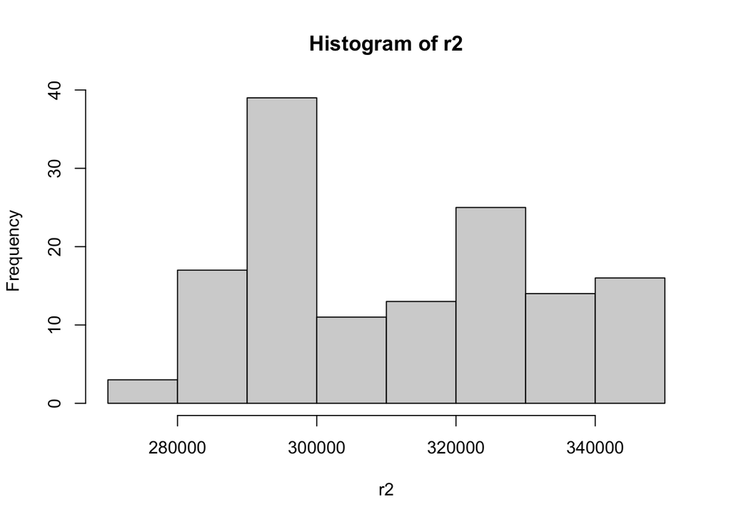

```r
library(NGScopyData)
tps_27 <- tps_27.chr6()$bamFpath
bf <- BamFile(tps_27)

gr <- GRanges("chr6", IRanges(260000, 360000))
num_reads <- countBam(bf, param = ScanBamParam(which=gr))[1,"records"]

reads <- scanBam(bf, params = ScanBamParam(what=c("pos", "strand"), which=gr))


r2 <- reads[[1]]$pos[reads[[1]]$pos > 270000 & reads[[1]]$pos < 350000]
hist(r2, breaks=6)
```

```r
strand_info <- reads[[1]]$strand
positive_strand <- strand_info[strand_info == "+"]
negative_strand <- strand_info[strand_info == "-"]

all.equal(length(strand_info), (length(positive_strand) + length(negative_strand)))
```

```
## [1] TRUE
```

```r
prop_positive <- mean(reads[[1]]$strand == "+")

# prop_positive <- length(positive_strand) / length(strand_info)
paste("proportion of reads on positive strand: ", prop_positive)
```

```
## [1] "proportion of reads on positive strand:  0.421407272586454"
```

```r
library(GenomicAlignments)
ga <- readGAlignments(bf)
num_reads <- length(ga)
paste("number of reads: ", num_reads)
```

```
## [1] "number of reads:  258230"
```

```r
granges(ga[1])
```

```
## GRanges object with 1 range and 0 metadata columns:
##       seqnames      ranges strand
##          <Rle>   <IRanges>  <Rle>
##   [1]     chr6 61412-61504      +
##   -------
##   seqinfo: 25 sequences from an unspecified genome
```

```r
mean_bp_per_reads <- mean(width(ga))
paste("mean number of base pairs per read: ", mean_bp_per_reads)
```

```
## [1] "mean number of base pairs per read:  93.0030283080974"
```

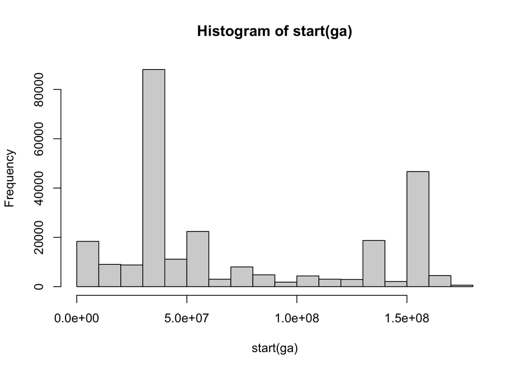

```r
hist(start(ga))
```

```r
# load GRanges with human genes
library(TxDb.Hsapiens.UCSC.hg19.knownGene)
txdb <- TxDb.Hsapiens.UCSC.hg19.knownGene
g <- genes(txdb)
```

```
##   403 genes were dropped because they have exons located on both strands
##   of the same reference sequence or on more than one reference sequence,
##   so cannot be represented by a single genomic range.
##   Use 'single.strand.genes.only=FALSE' to get all the genes in a
##   GRangesList object, or use suppressMessages() to suppress this message.
```

```r
# subset to genes on chr6
g_chr6 <- g[seqnames(g)=="chr6"]

g_sum <- summarizeOverlaps(features=g_chr6,
                           reads=bf,
                           ignore.strand=TRUE)

total_counts <- colSums(assay(g_sum))
paste("total number of counts: ", total_counts)
```

```
## [1] "total number of counts:  109735"
```

```r
num_zero_count_genes <- length(assay(g_sum)[assay(g_sum) == 0])
paste("number of genes with count of 0: ", num_zero_count_genes)
```

```
## [1] "number of genes with count of 0:  192"
```

```r
widths <- width(g_chr6)
count <- assay(g_sum)
fpm <- (count / sum(count)) * 1e6
maximum_fpm <- max(fpm)
paste("maximum fpm: ", maximum_fpm)
```

```
## [1] "maximum fpm:  384608.374720919"
```

```r
fpkm <- (fpm / widths) * 1e3
median_fpkm <- median(fpkm)
mean_fpkm <- mean(fpkm)
paste("median fpkm: ", median_fpkm)
```

```
## [1] "median fpkm:  3.38514591469009"
```

```r
paste("mean fpkm: ", mean_fpkm)
```

```
## [1] "mean fpkm:  26.5418981521175"
```

```r
num_genes_fpkm_gt_1000 <- length(fpkm[fpkm > 1000])
paste("number of genes with fpkm over 1000: ", num_genes_fpkm_gt_1000)
```

```
## [1] "number of genes with fpkm over 1000:  2"
```

```r
index_where_fpkm_gt_1000 <- which(fpkm > 1000)
top_entrez <- unlist(names(g_chr6[index_where_fpkm_gt_1000]))

output <- AnnotationDbi::select(org.Hs.eg.db, keys=top_entrez, keytype = "ENTREZID", columns = "SYMBOL")
output
```

```
##   ENTREZID  SYMBOL
## 1     1026  CDKN1A
## 2     7128 TNFAIP3
```